# Melbourne Restaurant Expansion: A Data-Driven Analysis of Business Longevity and Location Risk

Zhang ZHANG 30170508

NOV 1, 2025

### 1 Abstract

This study investigates the factors influencing restaurant survival in Melbourne’s inner-city hospitality sector, combining statistical modelling with interactive data visualisation. Using integrated datasets from the City of Melbourne’s CLUE Business Census (2002–2023) and Pedestrian Counting System (2009–present), the analysis covers 4,200 businesses across two major industries: restaurant and takeaway food services. Analytical methods include exploratory data analysis (EDA), principal component and clustering analysis for spatial grouping, random forest modelling for feature importance, and correlation-based relationship validation.

Results reveal that competition density is the most critical determinant of business longevity among those examined factors, while restaurant size and foot traffic exerts a positive but nonlinear effect. Suburb-level differences exist but no single postcode guarantees success. The accompanying Shiny application extends these findings into an interactive decision tool, enabling users to explore success profiles, spatial patterns, and survival distributions by area and street. Collectively, the analysis provides both actionable insights and strategic guidance for location-based expansion planning in Melbourne’s restaurant market.

### 2 Background and Motivation

Melbourne’s hospitality industry is characterised by rapid market turnover and high competition density, with thousands of restaurant and takeaway food services competing for limited consumer attention. Despite ongoing market growth, survival rates remain low, particularly for small-scale operators entering prime dining precincts. Understanding the determinants of business longevity is therefore essential for strategic site selection, investment prioritisation, and urban planning.

The project was developed in response to a consulting brief for a fast-growing Asian dining group established in 2023, currently expanding from Queensland and New South Wales into Victoria. The client sought a data-driven framework to guide expansion into Melbourne, aiming to identify optimal areas and understand which local environmental factors most strongly affect long-term success.

The analysis leverages two complementary open-data sources:

- City of Melbourne’s CLUE Business Census (2002–2023) — providing longitudinal business records across 15 CLUE areas and 317 streets; and
- Pedestrian Counting System (2009–present) — offering hourly foot-traffic data from 143 sensors across the central municipality.

Integrating these sources enables a multi-level assessment of market structure, competition intensity, and environmental exposure, providing a rare opportunity to study business survival patterns at both property and street level.

This project is motivated by the practical need to bridge descriptive market profiling and quantitative survival modelling. While prior business studies often rely on predictive accuracy, this research emphasises interpretability and factor understanding, aligning with managerial decision contexts.

Furthermore, by incorporating an interactive Shiny dashboard, the project delivers an accessible tool for exploration and stakeholder engagement, translating complex statistical findings into usable insights for strategic planning.

In short, this study addresses the client’s key business questions — the current market landscape, risk hotspots, the effect of competition, business size and foot-traffic — using CLUE and pedestrian data covering approximately 4200 businesses across 15 CLUE areas and 105 streets.

### 3 Objectives and Significance

The primary objective is to identify and quantify the key factors that influence restaurant longevity in Melbourne’s competitive dining landscape. Specifically, the study aims to:

• Examine spatial and structural patterns in business survival across areas and streets.

• Evaluate the relative importance of environmental and operational factors (competition, size, foot traffic, and location) using interpretable machine-learning and statistical methods.

• Explore how factor effects interact across lifecycle stages and business contexts.

• Translate findings into an interactive decision support system (Shiny app) that profiles markets, benchmarks street performance, and visualises success patterns.

The significance of this research lies in its contribution to evidence-based location strategy and market risk assessment. The results provide empirical clarity on common industry assumptions — notably challenging the perceived value of high-foot-traffic areas, while quantifying the dominant role of local competition.

From an analytical standpoint, combining Random Forest modelling, PCA clustering, and lifecycle-stage correlation analysis offers a multi-angle understanding of business dynamics that balances interpretability and robustness.

Practically, the findings guide decision-makers to optimise restaurant size within budget constraints, avoid multi-tenant properties with saturated competition, and prioritise moderate-competition areas that show consistent performance. The inclusion of an interactive Shiny dashboard extends these insights beyond static reporting, offering a transparent, visual, and repeatable framework for evaluating new sites — transforming data analysis into a decision-ready tool for strategic restaurant expansion in Melbourne.

### 4 Data and Methodology

#### 4.1 Data Sources

Two open datasets from the City of Melbourne Open Data Portal form the foundation of this analysis.

- Cafes and Restaurants with Seating Capacity (CLUE Business Census, 2002–2023)

- Pedestrian Counting System (2009–present)

This dataset provides hourly bi-directional pedestrian flow data collected from over 140 sensors distributed across Melbourne’s activity hubs. Each sensor record contains a unique sensor ID, activation status, location coordinates, and directional flow counts. These sensors are positioned strategically based on retail density, pedestrian patterns, and event proximity. The dataset contributes an environmental exposure dimension, linking street-level foot traffic intensity to business outcomes. The data can be retrieved via the[City of Melbourne Open Data Portal](https://data.melbourne.vic.gov.au/explore/dataset/pedestrian-counting-system-sensor-locations/information/)

#### 4.2 Methodological Overview for Data Aggregation

The goal of data aggregation was to transform raw, inconsistent business and environmental data into a clean, integrated, and bias-aware dataset suitable for analytical modelling and visualisation. The process involved five key methodological steps:

- data cleaning and standardisation,
- business identity resolution,
- bias mitigation through temporal filtering,
- geographic aggregation for spatial context, and
- temporal segmentation for lifespan classification.

#### 4.3 Data Cleaning and Standardisation

Initial cleaning focused on resolving inconsistencies and outliers in the CLUE data.

• Missing values (NA):

Records with missing core identifiers (such as business name, address, or coordinates) were excluded because their absence prevents reliable linkage or spatial analysis. For other missing attributes, no imputation was performed to avoid introducing artificial variance.

• Extreme seating values:

Businesses with seating capacities greater than 200 seats were removed, as they represent unusually large establishments (e.g., event venues) outside the client’s operational scope. These outliers also distort distributional statistics and correlation measures.

• Coordinate precision:

Geographic coordinates were rounded to a consistent precision to ensure alignment with foot-traffic sensors and to prevent false uniqueness caused by minor decimal differences. These cleaning procedures established a consistent foundation for further processing while preserving representativeness across areas and industries.

#### 4.4 Business Identity Resolution

One of the most substantial methodological challenges was reconciling inconsistent business identifiers over time. The CLUE dataset records the same premises repeatedly across years but with variations in trading names, abbreviations, or address formats. To create a reliable longitudinal view, a multi-stage identity resolution algorithm was applied:

- Exact and fuzzy name matching corrected typographical differences and brand variations (e.g., “Café Latte” vs “Cafe Latte”).
- Fuzzy address alignment harmonised inconsistent or partially recorded street information.
- Coordinate clustering grouped records within a defined spatial tolerance, assuming minor positional shifts represented the same venue.

The output was a unified business_id variable that accurately tracked businesses across all 22 years. This enabled consistent measurement of lifespans and transitions between years.

#### 4.5 Bias Mitigation through Temporal Filtering

To ensure unbiased lifespan estimates, two bias filters were applied.

- Survivorship Bias Filter (Right-Censoring):

Businesses that opened recently (and are still operating) appear to have “short” lifespans simply because they have not yet closed. To avoid underestimating longevity, these ongoing businesses were excluded from statistical lifespan analysis but retained for descriptive profiling and visual storytelling within the Shiny dashboard.

- Early-Record Bias Filter (Left-Censoring):

Some businesses existed before CLUE began in 2002. If these were treated as new entrants, their true duration would be understated. A secondary filter therefore excluded any businesses whose first recorded year coincided with the dataset’s start, preventing systematic underestimation of long-lived establishments.

- Completion Lifespan Filter (Right-Censoring Control)

To ensure lifespan results reflect complete business trajectories, only businesses with known closure dates were included in modelling. Those still operating at the end of the observation period were excluded, as their true duration is unknown.

This prevents right-censoring bias—where ongoing businesses appear “short-lived” simply because their closure has not yet occurred—and ensures all predictive models are based on fully observed outcomes.

Together, these 3 filters ensure that only businesses with complete life cycles are used in duration-based models, while all others contribute to descriptive summaries.

#### 4.6 Competition Measurement (200 m Buffer)

Each business was geocoded and linked to surrounding establishments within a 200-metre radius, representing a realistic local catchment and walking-distance competition zone. The buffer was defined based on the business’s opening year, ensuring that only competitors active at the same time were counted and avoiding future data leakage.

Two indicators were derived to capture distinct aspects of the competitive environment:

- Same-industry competition counts nearby businesses in the same category (e.g., restaurants near restaurants), reflecting direct market rivalry.
- Other-industry competition counts neighbouring businesses from different categories (e.g., restaurants near takeaway), capturing indirect competition and overall commercial density.
- Analysing both allows differentiation between true competitive pressure within a market segment and general retail congestion, helping identify whether survival patterns depend more on rivalry intensity or on the vibrancy of mixed-use surroundings.

#### 4.7 Foot Traffic Data Aggregation

Pedestrian sensor data from the City of Melbourne’s open dataset were aggregated to produce consistent, interpretable measures of urban foot traffic. Hourly pedestrian counts were first summed to daily totals per sensor, then averaged by year to create an annual profile of pedestrian activity. A further multi-year summary was derived for each sensor, capturing its long-term average daily flow (avg_daily_overall) and total cumulative traffic (total_all_years). This hierarchical aggregation—from hourly to daily, yearly, and multi-year levels—ensures temporal consistency and reduces random fluctuations, allowing direct integration with business data for spatial analysis.

The resulting summaries capture both temporal coverage and spatial coverage. These aggregated metrics enable consistent linkage with business data, allowing analysis of how foot-traffic intensity correlates with business survival across Melbourne.

#### 4.8 Foot Traffic Aggregation and Coverage

Each business was also spatially linked to the nearest pedestrian sensor within 200 metres to estimate average daily foot-traffic exposure. This matching connected business locations to Melbourne’s sensor network, allowing us to integrate human-movement data as a proxy for local demand and visibility.

Because pedestrian sensors do not cover all areas, this dataset includes approximately 75% of businesses. To maintain full spatial representation, foot traffic was excluded from clustering analyses but incorporated later in the modelling stage (Section 4.8) to assess its direct contribution to business lifespan.

This approach provides consistent spatial metrics for both competitive intensity and environmental opportunity, linking each business to its surrounding market and pedestrian context.

#### 4.9 Diagnostic and Robustness Checks

To evaluate the robustness of spatial aggregation, multiple buffer distances were tested (50 m, 75 m, 100 m, 125 m, 150 m, 200 m, and 300 m).

The resulting competition metrics produced similar relationships and model performance across the 50–200 m range. A radius of 200 m was selected for the final analysis because it yielded the highest R² in regression tests while maintaining intuitive interpretability as a typical walking distance. This consistency across distances indicates the spatial findings are robust to reasonable variations in buffer definition.

#### 4.10 Temporal Segmentation for Lifespan Analysis

To facilitate structured interpretation, businesses were grouped into lifespan categories (e.g., 0–2, 3–5, 6–8, 9–12, and >12 years). This segmentation allows the comparison of factor effects across distinct stages of the business lifecycle — for instance, identifying which attributes matter most during the startup stage versus long-term sustainability.

Temporal segmentation also supports clear visualisation within the Shiny app, enabling users to explore longevity patterns interactively by category rather than treating lifespan as a continuous variable.

#### 4.11 Analytical Methods

The analysis employs four complementary methodological approaches to address the research objectives:

- Exploratory Data Analysis

Initial profiling of business distributions, survival patterns, and temporal trends across areas and industries. Summary statistics, visualizations, and correlation analysis establish baseline understanding of market structure.

- Clustering Analysis

To identify natural groupings in the spatial data, we apply clustering algorithms. This reveals distinct market profiles based on competition density, foot traffic patterns, and geographic characteristics. Results inform area segmentation for targeted analysis.

- Random Forest Modelling

A Random Forest regression model quantifies the relative importance of environmental factors in explaining business longevity. The model provides variable importance rankings, enabling prioritization of strategic factors. Cross-validation ensures robustness and generalizability.

- Correlation and Interaction Analysis

Stage-specific correlation analysis examines how factor relationships vary across business lifecycle phases. Interaction effects between competition and foot traffic are explored to identify optimal market configurations.

#### 4.12 Functional Aspects of the Shiny Application

The Shiny dashboard translates the cleaned, bias-filtered dataset into an actionable, exploratory decision-support system. It enables stakeholders to interrogate where venues succeed, how long they last, and which local conditions (competition, size, location) co-vary with longevity. The tool complements the statistical analysis by exposing the same data-generation rules (identity resolution; two bias filters; 200 m competition context) through consistent filters and summaries.

**A.** Interactive Business Location Map (profile & density view)

Dual temporal views: Historical (completed lifecycles) vs Current (operating in 2023) to avoid survivorship bias when exploring longevity patterns.

Targeted filtering: Industry selector and lifespan bands (1–2, 3–5, 6–8, 9–12, >12 years) allow users to isolate maturity tiers.

Rich pop-ups (business profile): Clicking a point reveals name, address, industry, measured lifespan, lifecycle status (e.g., “Long-term Success (Closed)”), and seating capacity—supporting micro-level due diligence.

Density & clustering cues: Visual concentration of points surfaces street- and area-level density; the Map Summary panel reports businesses shown, average lifespan, and success rate for the active filters, turning the map into a quick situational report.

Decision use: Identify pockets of long-lived venues, cross-check whether density reflects healthy agglomeration or risky crowding, and shortlist candidate micro-locations before deeper street benchmarking.

**B.** Geographic Success Heatmap (area × industry matrix)

Success threshold slider (2/5/15 years) stress-tests how the interpretation changes under different definitions of “success.”

Matrix by CLUE area × industry presents area-level business survival rates, highlighting neighbourhoods with relatively higher or lower long-term success.

• Decision use: Helps quickly identify high-performing local areas and test whether these performance patterns remain consistent when the success threshold changes. This supports broader location profiling rather than prediction for any single cuisine type.

**c.** Business Duration Patterns (distribution & context statistics)

Selectable industry + area returns the full lifespan histogram for businesses meeting the bias-free criteria.

Context metrics: On-panel statistics (total n, median lifespan, short-term share, success rate) provide local operating context at a glance.

Decision use: Gauge variability and tail risk (e.g., short-term failure prevalence) before committing to a precinct.

**D.** Street Performance Comparison (peer benchmarking)

Side-by-side street benchmarking (up to three streets) shows:

Historical businesses, average lifespan, success rate (>12 y), current businesses, average seats (2023), and 200 m competition density;

Peer context via vs Area Benchmark (street delta vs its CLUE area);

Linked charts for success rate and current competition to visualise trade-offs.

Decision use: Compare a candidate street with local peers to understand whether its performance is exceptional or reflects broader area effects; confirm the number of businesses (market depth) and whether current crowding is already high.

**E.** Design principles & implementation notes

Analytical fidelity: All modules reflect the same preprocessing rules (identity resolution, two bias filters, 200 m competition radius, removal of extreme >200-seat venues, no imputation).

Transparency: Panels surface the denominators and definitions (e.g., completed lifecycles, threshold years), preventing misinterpretation.

Technology: Built with shiny, leaflet, plotly, and tidyverse; responsive layout for desktop review sessions with clients.

Role in the study: The Shiny application was developed at the client’s request as a descriptive and exploratory profiling tool rather than a predictive model. It enables the client to interactively explore location- and business-level patterns—such as where long-lived businesses cluster, how competition density varies by area, and how lifespan distributions differ across precincts.

By integrating the underlying analytical framework into a visual interface, the app enhances interpretability, communication, and scenario exploration, supporting evidence-based discussions about precinct and street selection while maintaining the project’s main analytical focus on understanding factor importance (competition, size, and location characteristics).

### 5 Data description

#### 5.1 Business Census data

The Cafes and Restaurants with Seating Capacity dataset is derived from the City of Melbourne’s Census of Land Use and Employment (CLUE). It contains annual records of business establishments located within the Melbourne local government area, spanning the years 2002 to 2023.The data can be retrieved via the [City of Melbourne Open Data Portal](https://data.melbourne.vic.gov.au/explore/dataset/cafes-and-restaurants-with-seating-capacity/information).

Table 1: Variable Types in CLUE Dataset

| Census year | Block ID | Property ID | Base property ID | Building address | CLUE small area | Trading name | Business address | Industry (ANZSIC4) code | Industry (ANZSIC4) description | Seating type | Number of seats | Longitude | Latitude | location |
| --- | --- | --- | --- | --- | --- | --- | --- | --- | --- | --- | --- | --- | --- | --- |
| numeric | numeric | numeric | numeric | character | character | character | character | numeric | character | character | numeric | numeric | numeric | character |

The Table 1 lists all variables in the dataset along with their data types. It contains numerical, categorical, and spatial fields, allowing for a wide range of analyses—from statistical modelling to geographic visualization. Overall, the variable names are clear and descriptive, making the dataset easy to interpret and suitable for both exploratory and predictive studies.

Table 2: Summary of Dataset Structure and Quality Checks

| Number of Rows | Number of Columns | Number of Duplicate Rows | Total Missing Values | Columns with NA Values | Names of Columns with NA Values | Non-positive Seating Values |
| --- | --- | --- | --- | --- | --- | --- |
| 55863 | 15 | 0 | 1461 | 3 | Longitude, Latitude, location | 0 |

Table 3: Unique Census Years in the Dataset

| Census Years |
| --- |
| 2002, 2003, 2004, 2005, 2006, 2007, 2008, 2009, 2010, 2011, 2012, 2013, 2014, 2015, 2016, 2017, 2018, 2019, 2020, 2021, 2022, 2023 |

Table 3 shows the dataset spans 22 census years, covering the period from 2002 to 2023.

Table 4: Unique Values of Seating Type and CLUE Small Area

| Seating Type | Seats - Indoor | Seats - Outdoor |  |  |  |  |  |  |  |  |  |  |  |
| --- | --- | --- | --- | --- | --- | --- | --- | --- | --- | --- | --- | --- | --- |
| CLUE Small Area | Carlton | Docklands | East Melbourne | Kensington | Melbourne (CBD) | Melbourne (Remainder) | North Melbourne | Parkville | Port Melbourne | South Yarra | Southbank | West Melbourne (Industrial) | West Melbourne (Residential) |

As we can see from Table 4, there are two seating configuration groups — Indoor and Outdoor — representing where customers are primarily served.

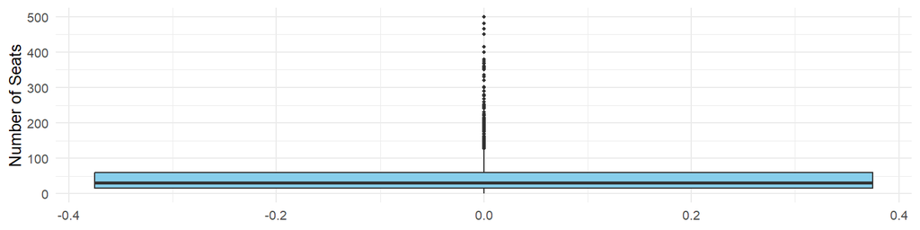

Figure 1: Distribution of Seating Capacity

Number of Seats is the only continuous numerical variable in the dataset.

Figure 1 shows that most businesses have fewer than 100 seats, though a few very large venues exist—likely major sites such as stadiums or racecourses.

| Industry_Type | Count |
| --- | --- |
| Cafes and Restaurants | 47314 |
| Takeaway Food Services | 8549 |

#### 5.2 Foot traffic data

Table 6: Variable Types in Sensor Traffic Dataset

| ID | Location_ID | Sensing_Date | HourDay | Direction_1 | Direction_2 | Total_of_Directions | Sensor_Name | Location |
| --- | --- | --- | --- | --- | --- | --- | --- | --- |
| dbl | dbl | date | dbl | dbl | dbl | dbl | chr | chr |

The Table 6 contains nine key variables capturing both temporal and spatial aspects of Melbourne’s pedestrian counting system. It includes sensor identifiers (ID, Location_ID), timestamped readings (Sensing_Date, HourDay), directional traffic counts (Direction_1, Direction_2, Total_of_Directions), and sensor metadata (Sensor_Name, Location). These variables provide a complete foundation for analysing hourly pedestrian movement, enabling aggregation into daily and yearly trends while maintaining spatial precision for mapping and cross-referencing with business data

Table 7: Summary of Sensor Traffic Dataset Structure and Quality Checks

| Number of Rows | Number of Columns | Number of Duplicate Rows | Total Missing Values | Columns with NA Values | Names of Columns with NA Values | Non-positive Daily Values |
| --- | --- | --- | --- | --- | --- | --- |
| 1412112 | 9 | 0 | 0 | 0 | None | 0 |

As shown in Table 7, the dataset contains 1,412,112 records and 9 variables, with no duplicate entries or negative seating counts. There are not missing values.

### 6 Exploratory Data Analysis (EDA)

In this section, we examine how business counts and other features evolve over time and across industries, forming the foundation for later clustering and modelling analyses.

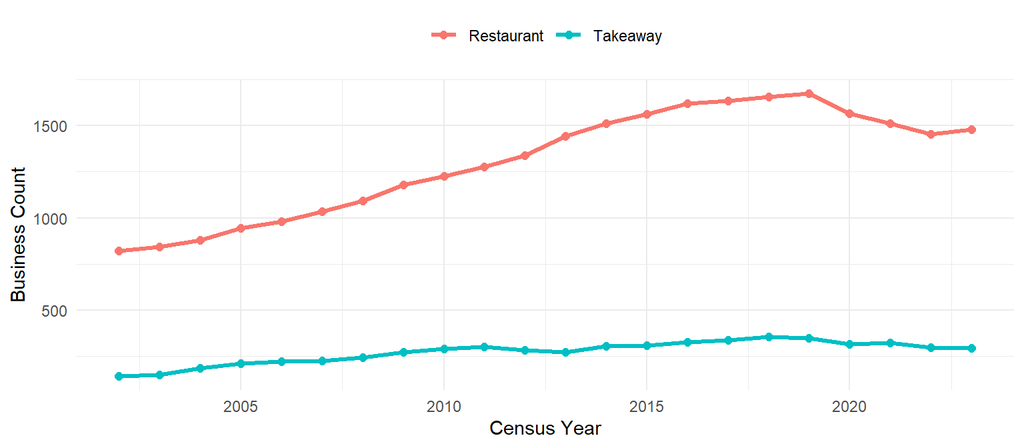

Figure 2: Trends in Business Count Over Time: Restaurants vs Takeaway

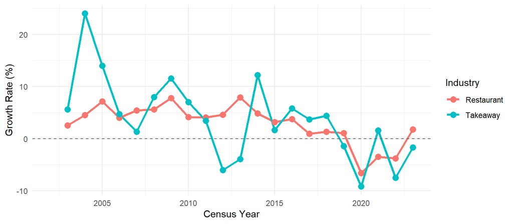

Figure 3: Business Growth Trends Over Time

Figure 3 reveals extreme early-period volatility, particularly for takeaways with 25% growth (2004) followed by sharp contractions. This pattern likely reflects both small-base effects (percentage changes appear extreme when n<100) and potential data collection improvements as the CLUE census matured. Early years may capture initial business registration waves rather than true market growth.

Takeaway growth rates swing wildly between -8% and +25% year-over-year. Restaurant growth fluctuates within ±8% range until 2020’s sharp decline. High volatility in takeaways suggests an immature market responding to external shocks. Restaurants show typical mature market patterns until crisis hits.

During COVID (2020-2021), the industries diverged dramatically: restaurants experienced sustained negative growth through 2021, while takeaways rebounded to positive territory by 2021. This suggests takeaway models provide crucial resilience during demand shocks, validating them as potential risk mitigation strategies for multi-format operators.

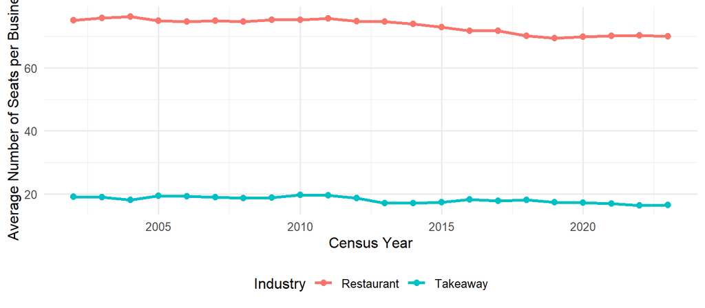

Figure 4: Average Seating per Business Over Time

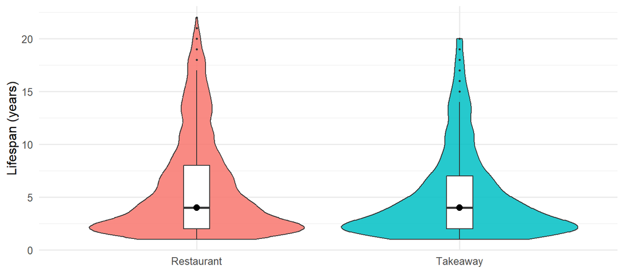

Figure 5: Distribution of Business Lifespan by Industry

From Figure 5 we observed nuanced survival patterns in the bias-corrected sample. Both industries show similar median lifespans (restaurants: 4 years, takeaways: 4 years), now identical after removing operating businesses. However, restaurants still exhibit slightly greater variance with more density in the upper range (8-15 years), though less extreme than before filtering. Takeaways show a more concentrated distribution around the median with minimal upper tail presence, confirming that few achieve institutional longevity even among closed businesses.

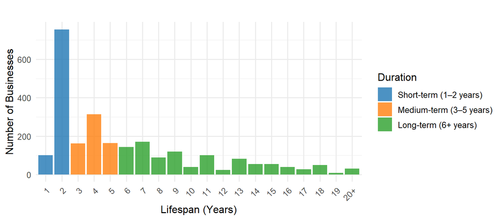

Figure 6: Restaurant Lifespan Distribution

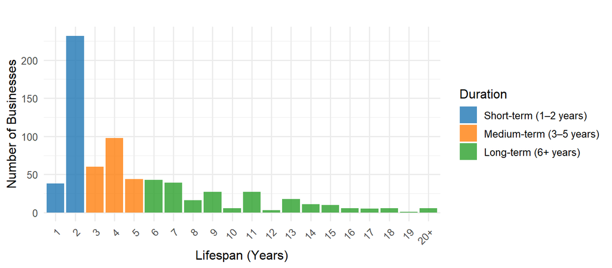

Figure 7: Takeaway Lifespan Distribution

Figure 6 and Figure 7 expose critical early-stage mortality patterns. Both industries suffer catastrophic Year 1-2 failures: restaurants lose 800+ businesses, while takeaways lose 250 businesses. This higher proportional failure rate for takeaways challenges assumptions about their lower-risk profile.

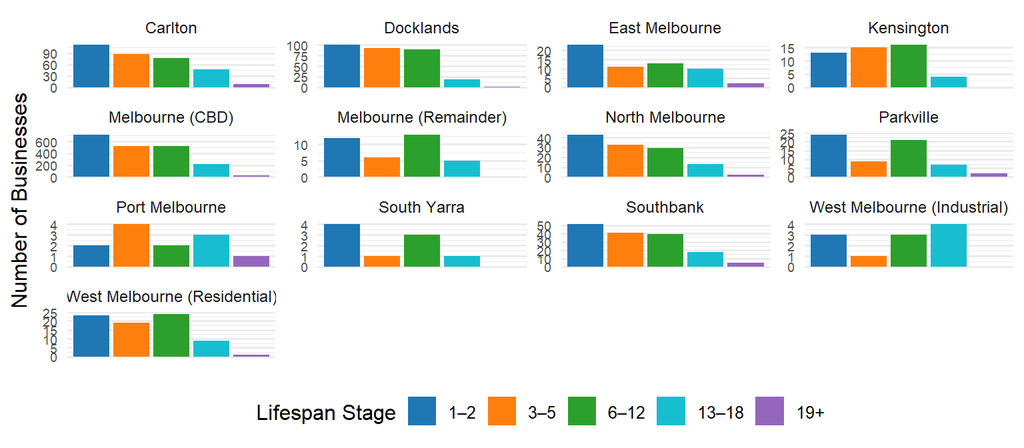

Figure 8: Business Lifespan Distribution by CLUE Area

Form Figure 8, we observe dramatic geographic variations in business lifecycle patterns:

*High Early-Stage Failure Areas

Melbourne CBD: Despite 600+ total businesses, maintains a similar proportional pattern of early failures

West Melbourne (Residential): Shows heavy early-stage concentration

*Balanced Distribution Areas:

North Melbourne & Kensington: Healthy representation across stages, suggesting sustainable market conditions

East Melbourne: Despite smaller numbers (~20), shows good lifecycle balance

*Limited Data Areas:

Port Melbourne, South Yarra, West Melbourne (Industrial): Too few businesses (≤4) for meaningful pattern analysis

#### Pedestrian Activity Hotspots

[interactive chart not shown]

Traffic density peaks overwhelmingly in Melbourne (CBD/Hoddle Grid). The hottest nodes align with Flinders St–Swanston St–Collins St corridors and around Flinders St Station/Bourke St Mall. This concentration is expected: the CBD combines (i) the city’s largest multimodal interchange (rail + tram), (ii) the highest daytime worker population, (iii) major retail anchors and visitor draws (laneways, malls, events), and (iv) short, walkable blocks that intensify pedestrian flow.

Spillover intensity is next strongest in Southbank (arts precinct, riverside promenade, Crown/Convention Centre) and parts of the east-end CBD; it drops sharply toward Docklands, West Melbourne, and the northern fringe, reflecting fewer transit nodes, wider blocks, and more office/residential land uses with lower all-day pedestrian churn.

Viable “busy-street” opportunities are highly localized—micro-site accuracy inside the CBD (and Southbank) matters far more than choosing a broad suburb label.

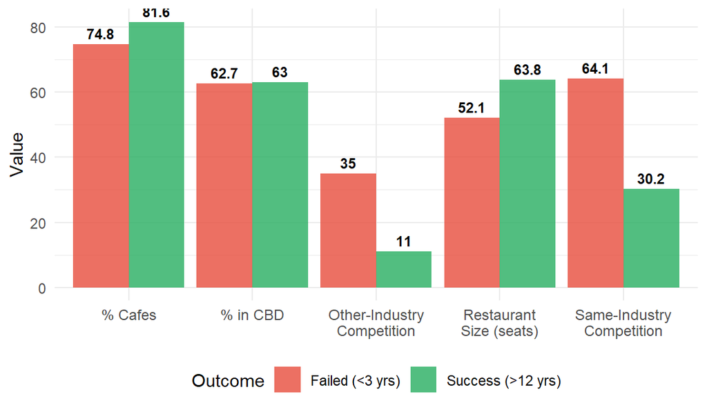

Figure 9: Success Profile: What Do Long-Term Survivors Have in Common?

From Figure 9, we compare 2,019 businesses that failed within 3 years against 624 businesses achieving >12 year success. The industry composition shows minimal difference—successful establishments are slightly more likely to be cafes (81.6%) versus restaurants compared to failures (74.8%). CBD concentration is virtually identical between groups (63.0% vs 62.7%), challenging assumptions about location primacy.

The most dramatic divergence appears in competitive environment. Successful businesses face less than half the same-industry competition of failures (30.2 vs 64.1 competitors within 200m), and one-third the other-industry competition (11 vs 35). Successful establishments also operate at larger scale, averaging 63.8 seats versus 52.1 for early failures—a 22% size premium.

Competition emerges as the dominant differentiator between success and failure, with a threshold effect around 30-35 same-industry competitors. The similar CBD presence between groups (63%) confirms that being in high-traffic areas alone doesn’t ensure success—what matters is the competitive density within those areas. The larger size of successful businesses likely reflects both cause and effect: operators with capital and confidence choose less saturated locations and build larger venues, which in turn provides operational advantages (economies of scale, menu diversity, event capacity) that enhance survival probability.

The 50% reduction in competition for successful businesses suggests they either: (1) strategically selected less saturated micro-locations from inception, (2) benefited from competitor attrition over time, creating breathing room, or (3) established strong positions that deterred new entrants. The 22% size advantage indicates successful operators invest more upfront, suggesting experience and capital—not just location—drive outcomes. The negligible difference in CBD presence reveals that market selection (Carlton vs Southbank vs CBD) matters less than tactical positioning within chosen markets.

#### 6.1 EDA Summary: Integrated Findings

The exploratory analysis reveals a market shaped by structural forces and geographic dynamics:

COVID resilience divergence: Takeaways’ rapid recovery versus restaurants’ prolonged struggles validates format diversification as risk mitigation. Our client’s full-service model should consider takeaway capabilities as defensive strategy.

Critical two-year cliff: Universal 35-45% mortality in years 1-2 transcends industry and geography, suggesting systemic challenges requiring targeted early-stage strategies rather than location selection alone.

These patterns inform our subsequent modeling by highlighting non-linear relationships between scale, competition, and survival requiring sophisticated analytical approaches beyond simple correlation analysis.

### 7 Clustering Analysis

We use clustering on areas and streets—combining longevity, competition, size, and variability—to uncover natural tiers of location quality. The patterns show a two-stage geography: area-level fundamentals drive survival, while street-level clusters refine choices within those high-quality areas.

While clustering incorporates all features simultaneously in multi-dimensional space, results are visualized using competition density versus mean lifespan—the two most strategically relevant dimensions for site selection decisions. This simplified presentation facilitates direct interpretation of the fundamental trade-off between market saturation and business longevity

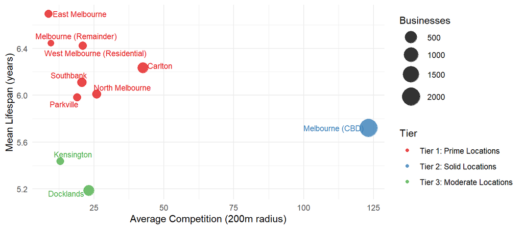

Figure 10: CLUE Area Performance: Lifespan vs Competition

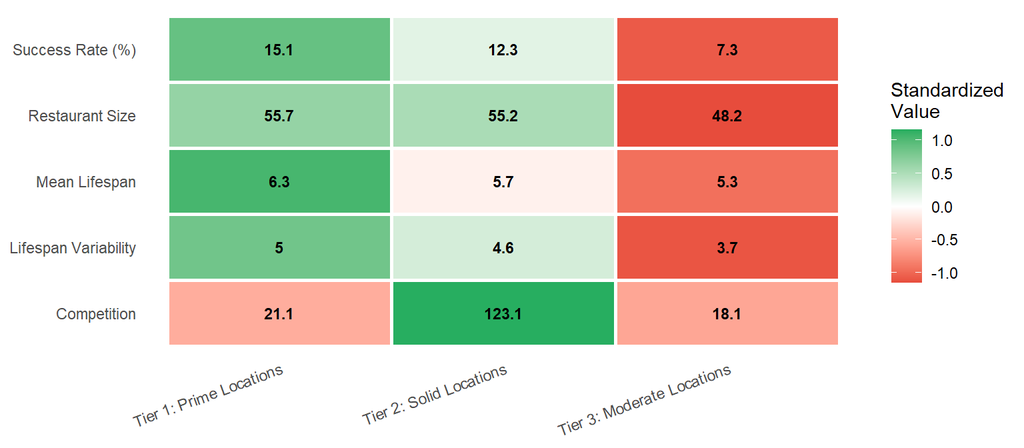

Figure 11: Cluster Characteristics Heatmap

Figure 11 quantifies the tier differences through standardized metrics. Tier 1 excels despite having slightly higher competition (21.1) than Tier 3 (18.1), achieving 15.1% success rate versus 7.3%. Tier 1 also features larger restaurants (55.7 seats), longer lifespans (6.3 years), and greater variability. Tier 2 shows extreme competition (123.1)—nearly 6x other tiers—yet maintains moderate success (12.3%). Tier 3 underperforms with the lowest metrics across all dimensions except competition.

This definitively disproves the “low competition = success” hypothesis. Tier 1 areas succeed with MORE competition than struggling Tier 3 areas, achieving double the success rate (15.1% vs 7.3%). The differentiator must be fundamental market quality—Tier 1 locations can support more competitors because they have superior customer bases, accessibility, or complementary businesses that create larger addressable markets.

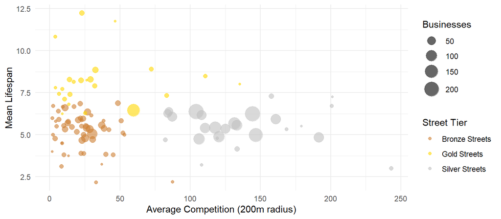

Figure 12: Street Performance: Lifespan vs Competition

Figure 12 indicates nuanced patterns at street level. While many Gold tier streets (yellow) cluster in the low-competition zone (<50 competitors), a striking outlier shows a large Gold street succeeding with 60+ competitors and substantial business volume. More revealing is the mixing of Gold and Bronze streets in the low-competition zone—both street types coexist at similar competition levels (<40) yet achieve vastly different outcomes (7.5-12.5 vs 0-7average lifespan).

Competition fails to fully explain street performance. The presence of successful Gold streets at higher competition levels, combined with Bronze street failures despite minimal competition, indicates critical unmeasured factors drive success. These likely include foot traffic patterns, anchor tenants, street accessibility, parking availability, or proximity to complementary businesses. The large Gold street outlier suggests that exceptional locations can sustain higher density when fundamental attractiveness justifies it—similar to our area-level finding where quality trumps competition

#### 7.1 Clustering Analysis Summary

The clustering analysis reveals that Melbourne’s restaurant geography operates on multiple, interacting levels:

Location quality trumps competition: The most striking finding is that Tier 1 areas actually have slightly MORE competition (21.1 competitors) than Tier 3 areas (18.1), yet achieve double the success rate (15.1% vs 7.3% in the bias-corrected sample). This definitively proves that competition density is not the primary driver of restaurant success. Instead, inherent area characteristics—likely including residential density, income levels, foot traffic patterns, and complementary retail—create the performance differential.

Competition tolerance varies by quality: Tier 1 areas demonstrate remarkable flexibility, thriving across a wide competition range (15-50 competitors). East Melbourne succeeds with minimal competition while Carlton prospers with 3x higher density. This variability within Tier 1 suggests high-quality locations can adapt to different competitive intensities, while Tier 3 areas fail uniformly despite low competition.

Scale effects persist: The difference in average restaurant size across tiers (55.7 vs 48.2 seats) remains substantial even after bias correction. Areas that attract operators willing to invest in 15% larger formats become successful, indicating location selection and operator quality are interlinked—professional operators recognize and invest in quality locations.

CBD operates as distinct market: Melbourne CBD’s extreme competition (123.1)—6x other areas—represents a fundamentally different ecosystem. Maintaining Tier 2 status (12.3% success) despite this density suggests unique demand drivers (tourists, office workers, events) create a larger addressable market with different survival dynamics than neighborhood-based locations.

Hierarchical market structure: The disconnect between area and street patterns reveals multi-scale effects. Areas show quality-driven performance (Tier 1 succeeds despite higher competition), while individual streets show competition sensitivity (Gold and Bronze streets intermingle at low competition but diverge in outcomes). This implies a two-stage selection process—first identify high-quality areas, then navigate street-level competition within them.

Hidden factors dominate: The mixing of Gold and Bronze streets at identical low competition levels (<30 competitors) indicates critical unmeasured variables drive success. These likely include micro-location factors (corner visibility, parking, transit access), anchor tenant effects, or temporal patterns (lunch vs dinner trade) that our competition metrics fail to capture.

### 8 Modelling and Determinants of Survival

Following exploratory and clustering analyses, predictive modelling was conducted to quantify how competition, exposure, and business characteristics jointly shape restaurant lifespan. Two complementary approaches were employed:

Random Forest (RF) — a non-linear ensemble method capturing complex, interactive effects (e.g., diminishing returns from foot traffic or saturation thresholds in competition).

Ordinary Least Squares (OLS) — a linear benchmark used to interpret coefficient direction and statistical significance, providing transparency and inference that RF lacks.

This dual-method design combines predictive accuracy with interpretability. The RF identifies which features truly drive survival, while OLS clarifies how they influence it. Together, they form a hybrid evidence base that balances data-driven power with economic reasoning.

Both models were trained using train-test splitting, with all continuous predictors standardized (z-scores). Random Forest hyperparameters were optimized via 5-fold cross-validation to ensure robust performance. Models were evaluated on the held-out test set using R², RMSE and comparison to baseline predictions.

Table 8: Table 9: Model Performance Comparison

| Model | Sample Size | Test R² | Test RMSE (years) | Overfit Check |
| --- | --- | --- | --- | --- |
| RF without Foot Traffic | 3200 | 0.147 | 4.19 | Normal |
| RF with Foot Traffic | 2450 | 0.273 | 3.97 | Good |

As shown on the table 8,two RF models were developed:

- Baseline model: all completed restaurants (n = 3,200).
- Enhanced model: subset including foot-traffic data (n = 2,450).

Despite the smaller sample, incorporating foot-traffic improved accuracy substantially (R²: 0.147 → 0.273; RMSE: 4.19 → 3.97 years, Figure 12). Overfit checks confirmed that the enhanced model generalised well.

Pedestrian activity adds measurable spatial context to survival prediction, reflecting the quality and vitality of trading environments beyond competition and area labels. Although foot-traffic data are biased toward central Melbourne, this bias aligns with the client’s target geography, making the model both representative and actionable.

Competition alone cannot explain performance variance among inner-city venues. Foot traffic captures ambient demand — the real-time potential customer base. By integrating this measure, the model transitions from describing where competition is low to explaining where opportunity endure

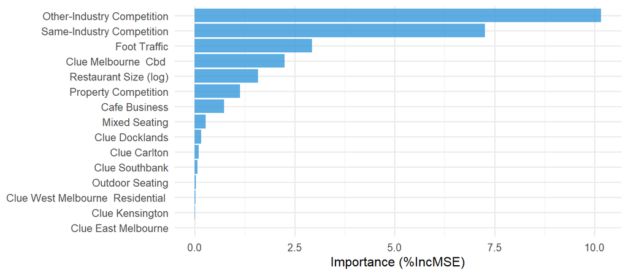

Figure 13: Feature Importance - Full Model with Foot Traffic

Feature ranking (Figure 13 ) confirms a consistent hierarchy across all model runs. Other-Industry Competition and Same-Industry Competition dominate predictive influence, jointly accounting for the majority of model variance. Foot Traffic emerges as the third most critical variable, followed by CBD location, Restaurant Size (log seats), and Business Model (Café vs Restaurant).

Competition constrains survival primarily through demand fragmentation. However, high-traffic corridors expand the effective catchment, sustaining adequate patronage despite dense clustering. This interplay between competition and exposure explains why some central zones remain viable even at extreme densities.

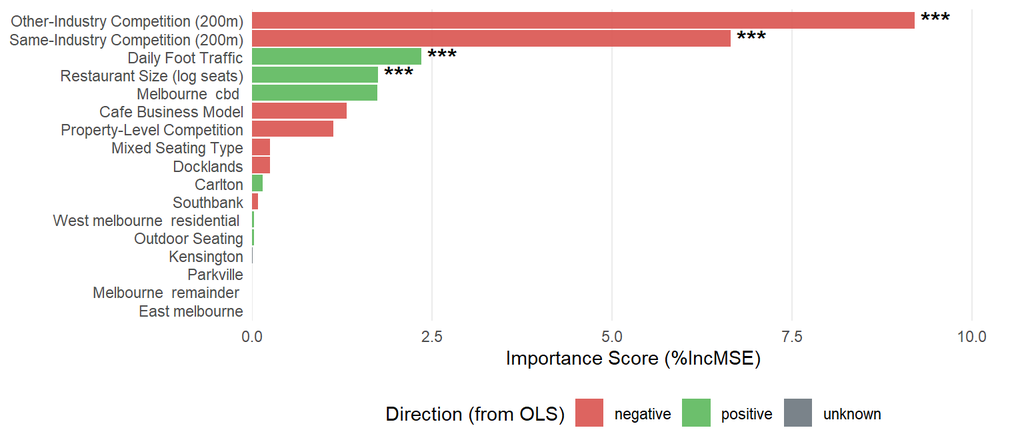

While Random Forest identifies which features matter, the OLS overlay (Figure 14 ) quantifies the direction and strength of these effects.

Competition effects: Both same- and other-industry counts are significantly negative (p < 0.001), confirming their consistent harm across all specifications.

Integrating OLS with RF adds interpretive precision: it distinguishes statistically robust drivers from artefacts of non-linear variance. The linear coefficients confirm that all top-tier variables are meaningful, while low-ranked area factors, despite measurable variance, lack statistical reliability.

OLS offers clarity on average effects, but it assumes constant slopes — an unrealistic simplification for urban systems with tipping dynamics. RF complements this by uncovering curvature and thresholds hidden in the residuals. The two methods are thus symbiotic: OLS explains direction, RF explains pattern.

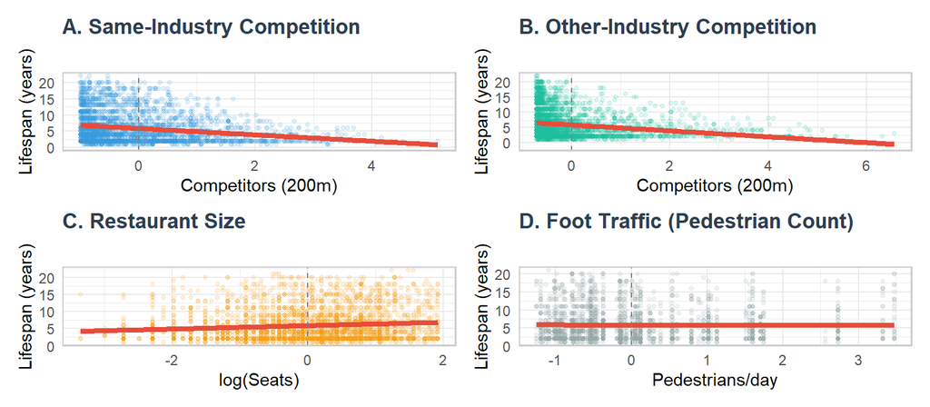

Figure 15: Feature comparison OLS

Linear regressions (Figure 15 ) of standardised features provide a baseline for comparison.

Same- and Other-Industry Competition show clear negative slopes, matching expectations.

Restaurant Size shows a mild positive correlation, while Foot Traffic appears near-flat under a linear specification.

At first glance, foot traffic seems inconsequential. However, its later importance within the non-linear RF model indicates that the effect is threshold-driven rather than proportional—only areas surpassing a certain pedestrian density see meaningful gains.

Linear methods fail to capture saturation or tipping effects inherent in urban systems. Pedestrian influence likely activates only beyond critical mass, where consistent passing flow translates into reliable custom. The RF model’s structure allows such non-linear thresholds to surface.

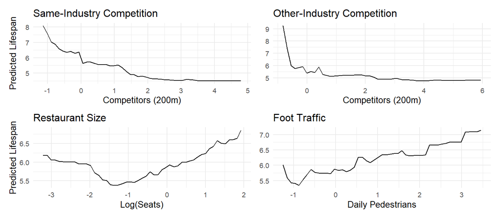

Figure 16: Partial Dependence Plots

Partial Dependence Plots (Figure 16 )illustrate marginal effects while holding other features constant, isolating pure influence patterns.

Same-Industry Competition: Lifespan declines sharply with the first few competitors and stabilises as competion increased, confirming a saturation threshold. Markets reach carrying capacity where additional competitors don’t further fragment demand—the pie is already fully divided. This explains why CBD businesses survive despite 20+ nearby competitors: beyond a threshold, competition intensity becomes background noise.

Other-Industry Competition: Similar steep decline, with wider range indicating broader crowding sensitivity. Marginal harm diminishes .

Restaurant Size: Exhibits a U-shaped pattern—micro-cafés and large venues outperform mid-scale operators, suggesting both niche and scale strategies can succeed. this indicates that those mid-size venues face the worst of both worlds—high fixed costs without scale benefits.

Foot Traffic: Nearly flat at low pedestrian levels, then climbs steadily beyond mid-range, confirming a non-linear exposure benefit.The relationship is non-compensatory — traffic can’t offset poor competition position

The PDP visualises the marginal return curve of each factor, revealing hidden dynamics: competition harm saturates early, while foot traffic benefits accelerate late. This asymmetric response explains why some dense areas remain profitable — high exposure compensates for market crowding.

The model implicitly captures market equilibrium — low-competition areas fail without sufficient demand, while high-competition zones remain viable only if traffic supports them. PDPs thus reconcile the earlier contradiction observed in clustering analysis: competition matters, but only relative to available demand.

#### 8.1 Section Summary

This modelling phase transforms prior descriptive insights into quantified causal patterns.

Random Forest isolates non-linear, interactive dynamics underpinning survival.

OLS provides statistical validation and interpretive transparency.

PDP visualises true marginal responses beyond linear simplification.

### 9 Interaction Analysis

The previous section established that competition intensity, size, and foot-traffic exposure are the dominant individual determinants of restaurant longevity. However, these factors rarely operate in isolation. This section examines how they interact — whether certain combinations reinforce or mitigate one another — to reveal the deeper structure of survival dynamics in Melbourne’s hospitality market. Figure 17 summarises these interaction effects across four panels, drawing on bias-corrected averages for completed restaurants.

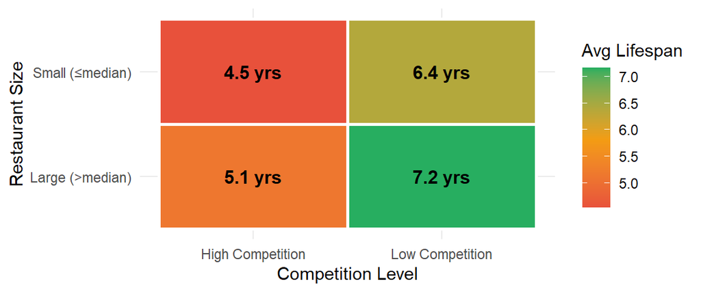

Figure 17: Competition x Size

Figure 17 compares restaurants above and below the median seating size under high- and low-competition conditions. A clear buffering pattern emerges: under high competition, small venues perform poorly (4.5 yrs) whereas larger ones fare moderately better (5.1 yrs). When competition is low, both size groups enjoy longer survival, but large venues again lead (7.2 yrs vs 6.4 yrs).

This indicates that scale offers resilience, likely through operational flexibility and brand visibility that help larger venues sustain profits in denser markets.

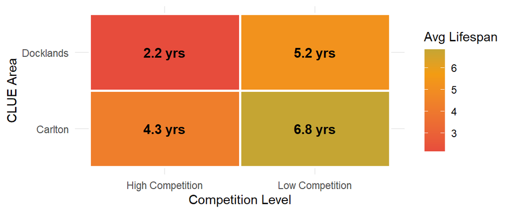

Figure 18: Competition × Area (Carlton vs Docklands)

From Figure 18, area-specific contrasts highlight spatial heterogeneity in competitive tolerance.

In Docklands, even moderate rivalry sharply reduces survival (2.2 yrs → 5.2 yrs). In Carlton, businesses exhibit greater durability (4.3 yrs → 6.8 yrs), suggesting stronger demand fundamentals and a more stable customer base.

Hence, competition interacts with local market maturity — well-established precincts absorb rivalry better than newly developed areas.

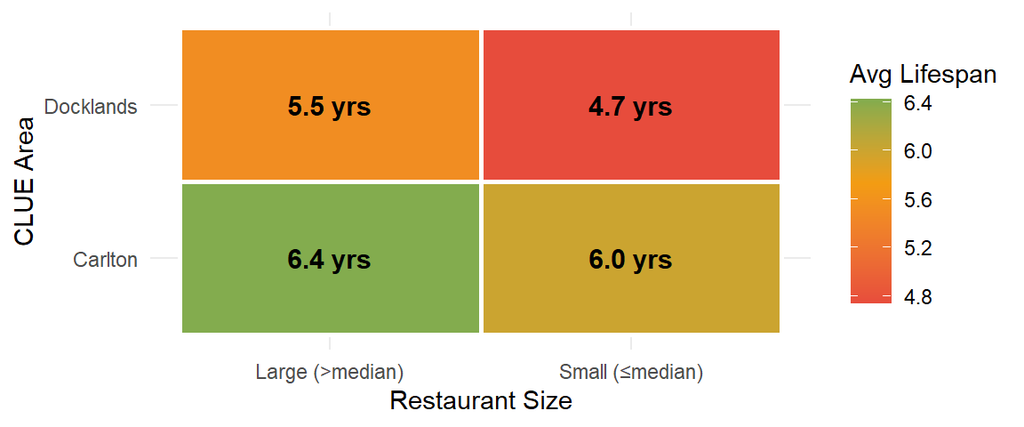

Figure 19: Size × Area

Figure 19 examines whether the benefits of scale vary by area. Size advantages are not uniform across locations.

In Carlton, both large and small venues achieve relatively long lifespans (6.4 yrs vs 6.0 yrs), implying balanced demand across scales.

Conversely, in Docklands, smaller operators underperform (4.7 yrs) relative to larger ones (5.5 yrs). This reinforces the notion that larger spaces confer stability where market demand is still forming or volatile, as they can better accommodate diverse offerings and customer volumes.

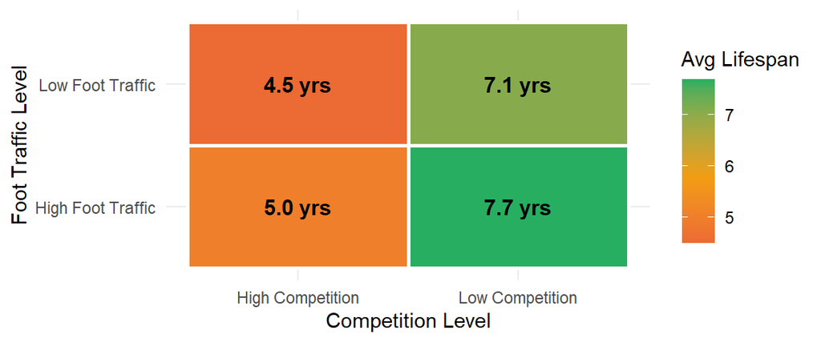

Figure 20: Competition × Foot Traffic

As shown on the (Figure 20 ), the strongest pattern appears when combining market pressure with pedestrian exposure.

Businesses located in high-traffic but low-competition zones achieve the longest average lifespan (≈7.7 yrs) — a natural sweet spot where strong customer flow is not diluted across too many rivals. Even under high competition, high-traffic locations (5.0 yrs) still outperform low-traffic ones (4.5 yrs), confirming that foot traffic acts as a contextual buffer against rivalry.

This outcome reflects the economic balance between demand and saturation:

High pedestrian counts ensure a steady inflow of potential customers, enhancing revenue stability.

Low competition prevents cannibalization, allowing each operator to capture a sustainable market share.

When both conditions co-exist, businesses can maintain higher utilisation and profit margins, reinforcing long-term survival.

#### 9.1 Summary

The Random Forest PDP (Figure 16 ) corroborates these patterns, showing that predicted lifespan rises steeply with higher foot traffic but flattens or declines under increasing competition. Together, the model-based and empirical findings confirm that foot traffic functions as a contextual buffer—it weakens the negative marginal effect of competition and helps sustain businesses that would otherwise struggle in crowded zones.

Overall, the interactions reveal that market success is multi-dimensional: optimal survival arises not simply from being in high-traffic or low-competition areas, but from balancing both. Larger venues amplify this advantage, while mature precincts like Carlton demonstrate greater structural resilience than newer zones such as Docklands. These cross-factor effects reinforce that business longevity depends on the interplay between spatial quality, demand intensity, and strategic positioning within the competitive landscape.

### 10 Lifespan Stage Analysis

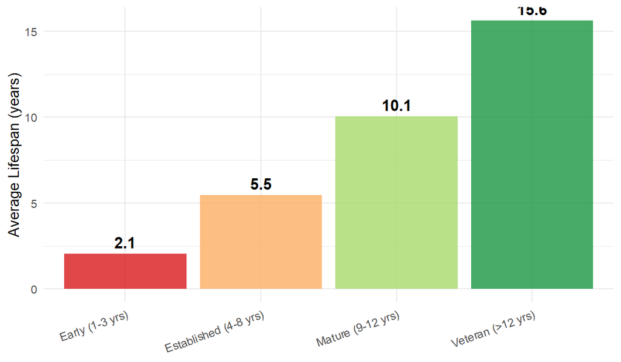

Figure 21: Average Lifespan by Stage

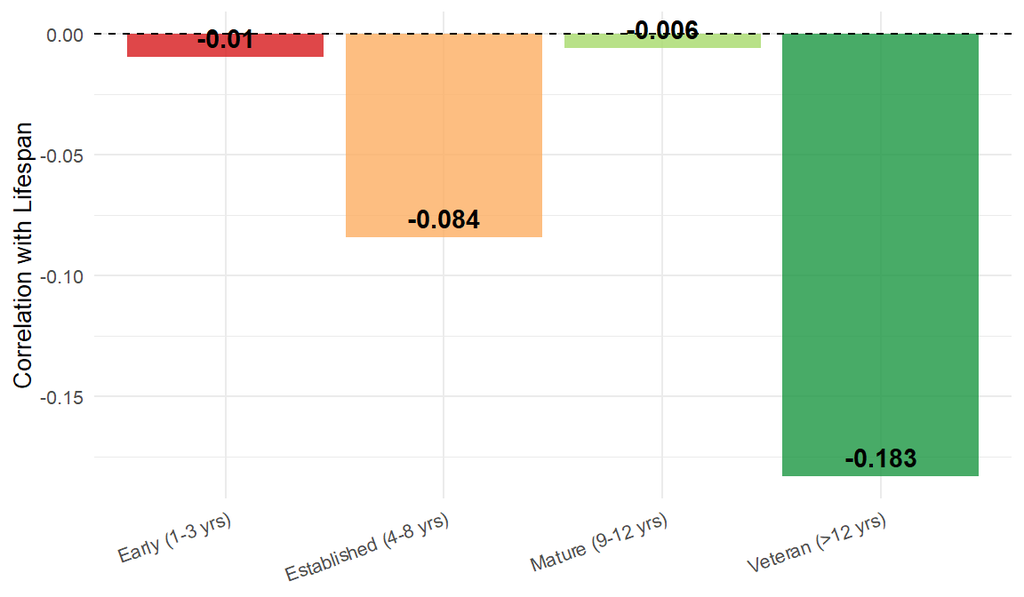

Figure 22: Competition Effect by Stage

Figure 22 reveals how the correlation between competition intensity and lifespan evolves across these stages. In the Early group, the relationship is negligible (r = -0.01), indicating that startups tend to fail or survive regardless of surrounding density. This neutrality likely reflects the dominance of internal factors such as capital adequacy and brand establishment in the first few years.

By the Established stage (4–8 years), the negative effect of competition becomes pronounced (r = -0.084). At this stage, operators have stabilised operations and are directly exposed to sustained market rivalry. The ability to differentiate becomes critical: outlets with undifferentiated offerings face erosion from newer entrants.

Among Veteran businesses (>12 years), the correlation intensifies to r = -0.183, the strongest observed. Paradoxically, long-established venues—though typically strong performers—show the greatest vulnerability to rising competition.

The competitive environment becomes more consequential as businesses age. Early-stage operators fail fast due to internal weakness, while mature operators are shaped increasingly by external market saturation. Veterans, though stable, are often entrenched in mature districts where new entrants compress margins, gradually shortening their lifecycle despite brand legacy.

As markets evolve, neighbourhoods with many long-lived venues also attract ongoing entry, increasing rivalry. Older operators must continually reinvest to sustain relevance, yet many maintain legacy formats that are less adaptive to shifting demand. Thus, long-term success paradoxically increases exposure to eventual decline through environmental crowding.

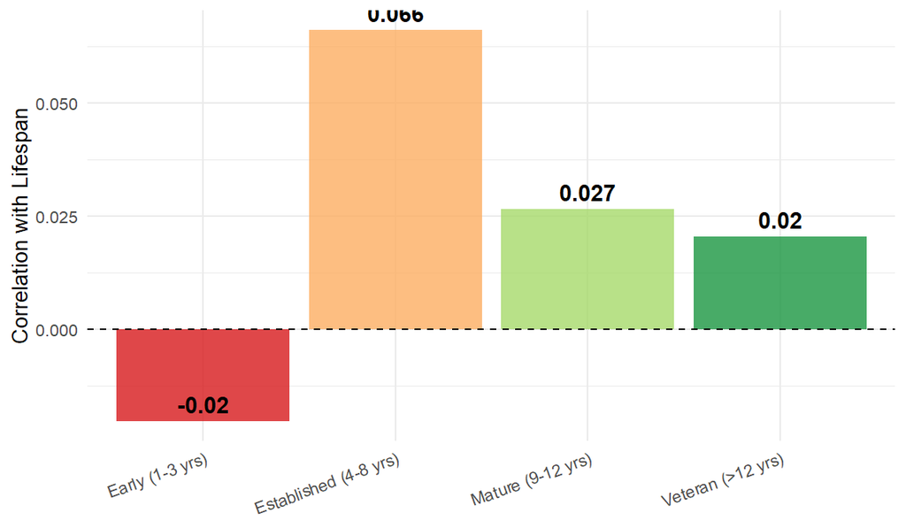

Figure 23: Size Effect by Stage

Figure 23 shows how the relationship between restaurant size and lifespan shifts across the lifecycle. In the Early stage, the correlation is slightly negative (r = -0.02), suggesting that large openings do not guarantee success; in fact, they may amplify risk when revenue streams are untested. This reverses sharply among Established businesses (r = +0.066), where scale becomes a meaningful advantage.

In the Mature and Veteran stages, the positive effect persists but diminishes (r = +0.027 and r = +0.020, respectively). This tapering implies that once scale has contributed to survival, its marginal benefit declines as other factors—brand equity, reputation, and area maturity—take precedence.

The value of scale is time-sensitive. Early large ventures often fail due to overextension, while mid-stage operators use scale to consolidate their market position. Over time, however, the incremental gains from additional capacity fade, producing diminishing returns to scale.

The cost-benefit balance of size changes with maturity. During the early years, capacity exceeds demand; during the growth phase, it enhances profitability; in later years, it becomes a fixed overhead risk as consumer habits or area demographics evolve.

#### 10.1 Summary

The stage-based results reveal a dynamic survival system governed by shifting dominance between internal and external pressures.

Early survival is determined by internal viability — capital structure, location quality, and managerial capability.

Mid-stage performance hinges on the ability to scale and differentiate within intensifying competition.

Late-stage endurance is eroded by accumulated competition and the inertia of legacy formats.

Competition therefore emerges as a lagging constraint—its influence grows only after businesses mature and markets saturate. Size, conversely, acts as a leading enabler, beneficial only once stability has been achieved.

Together, these findings contextualise the earlier Random Forest and interaction results: the same variables that predict overall success do so through distinct mechanisms at each stage of business evolution.

### 11 Conclusion

This analysis provides an evidence-based understanding of how market structure, competition, and spatial context relate to business survival in Melbourne’s hospitality sector. Through exploratory, clustering, and model-based approaches, we evaluated which environmental and operational factors appear most associated with longevity.

Overall, the analysis successfully addressed the client’s questions regarding market landscape, competition impact, geographic risk, business sizing, and the value of foot traffic. The results reveal consistent, interpretable patterns that clarify the relative importance and direction of the client’s factors of interest, rather than prescribing deterministic actions.

Market structure and geography: Mature precincts such as Carlton and the CBD maintain higher survival averages, while transitional areas like Docklands exhibit lower longevity and greater volatility.

Size and resilience: Larger venues consistently outperform smaller ones, particularly under competitive pressure, confirming that scale enhances stability through operational flexibility and brand presence.

Foot traffic and demand: Pedestrian exposure is a strong positive contextual factor, offsetting competition disadvantages and sustaining performance across diverse areas.

Interactions among factors: The most favourable configuration combines low competition with high foot traffic (average lifespan ≈7.7 years), representing balanced access to demand without excessive rivalry.

These findings align with the Random Forest and OLS results, which together indicate that the selected measurable features explain around 27% of lifespan variance, leaving approximately 73% influenced by other unobserved factors such as rent, cuisine positioning, and managerial capability. Hence, the analysis should be viewed as diagnostic and descriptive—a foundation for strategic understanding rather than prescriptive decision-making.

### 12 Recommendations

While the analysis identifies clear directional insights, the results do not warrant direct operational action on their own. Decisions should integrate financial feasibility, brand strategy, and qualitative assessment of each site.

- Interpret findings as directional guidance.

The relationships provide clarity on which environmental factors correlate with longevity but do not guarantee success. Insights should be used to inform further investigation or screening, not definitive site selection.

- Balance scale with budget.

Although larger venues display longer survival, expansion should always consider financial constraints and expected revenue density. For many operators, the optimal approach is moderate scaling within sustainable budgets, rather than unconditionally pursuing maximum capacity.

- Stage-specific considerations.

The life-stage analysis suggests that early-stage ventures (0–3 years) benefit more from stability and demand concentration than from aggressive competition avoidance or large-scale investment. In early years, modest size and manageable overheads may improve survival odds, while low competition and strong foot traffic remain advantageous.

In contrast, mature operators can better leverage scale to secure market share and absorb competition shocks.

- Strategic interpretation.

The model framework should serve as a decision-support lens, allowing clients to explore “what-if” scenarios under varying competition and traffic conditions, rather than as a tool for direct prediction or investment recommendation.

### 13 Limitations

- Limited explanatory power

The model explains 27% of variation in lifespan, meaning that most differences arise from factors not captured in the dataset. This includes management capability, price positioning, brand strength, and economic conditions.

Descriptive rather than predictive

The analysis identifies relationships but cannot confirm causation. Patterns reflect associations from historical data, not guaranteed future outcomes.

- Data coverage and granularity

Foot traffic sensors represent only sampled streets, and competition measures may not reflect qualitative differences between businesses. Time-specific variation (seasonality, events, or renovation periods) remains unaccounted for.

- Survival bias

Only completed business lifecycles were analysed, excluding active firms that may still survive or fail in the future. This biases lifespan averages downward.

- Simplified categorisation

Median or quantile splits in interaction plots simplify continuous variables for interpretability but may obscure nonlinear patterns.

- External influences

Economic shocks (COVID-19, rental surges, consumer behaviour shifts) likely distort observed trends, limiting generalisability to future market conditions.

### 14 Future Data Enhancements

To improve explanatory power and support more confident strategy design, future work should expand the dataset beyond environmental indicators. Recommended enhancements include:

Rental costs: quantify economic barriers and profitability trade-offs.

Street segmentation: divide long roads into functional blocks for finer spatial precision.

Cuisine type and price point: control for market positioning (e.g., fine dining vs. takeaway).

Online ratings and reviews: proxy for service quality and consumer satisfaction.

Demographic profiles: capture local income, age, and population density.

Economic and mobility indicators: integrate unemployment rate, tourism flow, and consumer sentiment trends.

Incorporating these dimensions will strengthen model reliability, refine competitive benchmarking, and enable the development of an interactive decision tool for future location profiling.

### 15 Reference

Wickham, H., François, R., Henry, L., & Müller, K. (2023). dplyr: A Grammar of Data Manipulation. [https://CRAN.R-project.org/package=dplyr](https://cran.r-project.org/package=dplyr)

Wickham, H., Averick, M., Bryan, J., Chang, W., D’Agostino McGowan, L., François, R., … Yutani, H. (2019). tidyverse: Easily Install and Load the ‘Tidyverse’. [https://CRAN.R-project.org/package=tidyverse](https://cran.r-project.org/package=tidyverse)

Müller, K., & Bryan, J. (2020). here: A Simpler Way to Find Your Files. [https://CRAN.R-project.org/package=here](https://cran.r-project.org/package=here)

Driessen, B., Phillips, S. J., & Driessen, J. (2023). galah: Download Biodiversity Data from the Atlas of Living Australia. [https://CRAN.R-project.org/package=galah](https://cran.r-project.org/package=galah)

Pebesma, E. (2018). sf: Simple Features for R. [https://CRAN.R-project.org/package=sf](https://cran.r-project.org/package=sf)

Bivand, R., Nowosad, J., & Lovelace, R. (2023). spData: Datasets for Spatial Analysis. [https://CRAN.R-project.org/package=spData](https://cran.r-project.org/package=spData)

Wickham, H. (2016). ggplot2: Elegant Graphics for Data Analysis. [https://CRAN.R-project.org/package=ggplot2](https://cran.r-project.org/package=ggplot2)

Urbanek, S. (2022). Cairo: R Graphics Device Using Cairo Graphics Library for Creating High-Quality Output. [https://CRAN.R-project.org/package=Cairo](https://cran.r-project.org/package=Cairo)

Zhu, H. (2021). kableExtra: Construct Complex Table with ‘kable’ and Pipe Syntax. [https://CRAN.R-project.org/package=kableExtra](https://cran.r-project.org/package=kableExtra)

Xie, Y., Allaire, J. J., & Grolemund, G. (2023). bookdown: Authoring Books and Technical Documents with R Markdown. [https://CRAN.R-project.org/package=bookdown](https://cran.r-project.org/package=bookdown)

Müller, K., & Wickham, H. (2023). tibble: Simple Data Frames. [https://CRAN.R-project.org/package=tibble](https://cran.r-project.org/package=tibble)

Henry, L., & Wickham, H. (2020). purrr: Functional Programming Tools. [https://CRAN.R-project.org/package=purrr](https://cran.r-project.org/package=purrr)

Xie, Y. (2023). knitr: A General-Purpose Package for Dynamic Report Generation in R. [https://CRAN.R-project.org/package=knitr](https://cran.r-project.org/package=knitr)

Wickham, H., Hester, J., & Bryan, J. (2023). readr: Read Rectangular Text Data. [https://CRAN.R-project.org/package=readr](https://cran.r-project.org/package=readr)

Wickham, H. (2019). stringr: Simple, Consistent Wrappers for Common String Operations. [https://CRAN.R-project.org/package=stringr](https://cran.r-project.org/package=stringr)

Chang, W., Cheng, J., Allaire, J. J., Xie, Y., & McPherson, J. (2023). htmltools: Tools for HTML. [https://CRAN.R-project.org/package=htmltools](https://cran.r-project.org/package=htmltools)

Wickham, H. (2023). scales: Scale Functions for Visualization. [https://CRAN.R-project.org/package=scales](https://cran.r-project.org/package=scales)

Cheng, J., Karambelkar, B., & Xie, Y. (2023). leaflet: Create Interactive Web Maps with the JavaScript ‘Leaflet’ Library. [https://CRAN.R-project.org/package=leaflet](https://cran.r-project.org/package=leaflet)

Maechler, M., Rousseeuw, P., Struyf, A., Hubert, M., & Hornik, K. (2023). cluster: Cluster Analysis Extended Rousseeuw et al. [https://CRAN.R-project.org/package=cluster](https://cran.r-project.org/package=cluster)

Kassambara, A., & Mundt, F. (2020). factoextra: Extract and Visualize the Results of Multivariate Data Analyses. [https://CRAN.R-project.org/package=factoextra](https://cran.r-project.org/package=factoextra)

Vries, A. de. (2022). ggdendro: Create Dendrograms and Tree Diagrams Using ‘ggplot2’. [https://CRAN.R-project.org/package=ggdendro](https://cran.r-project.org/package=ggdendro)

Pedersen, T. L. (2020). patchwork: The Composer of Plots. [https://CRAN.R-project.org/package=patchwork](https://cran.r-project.org/package=patchwork)

Therneau, T. M. (2023). survival: Survival Analysis. [https://CRAN.R-project.org/package=survival](https://cran.r-project.org/package=survival)

Kassambara, A., & Kosinski, M. (2021). survminer: Drawing Survival Curves Using ‘ggplot2’. [https://CRAN.R-project.org/package=survminer](https://cran.r-project.org/package=survminer)

Wickham, H., & Girlich, M. (2023). tidyr: Tidy Messy Data. [https://CRAN.R-project.org/package=tidyr](https://cran.r-project.org/package=tidyr)

Liaw, A., & Wiener, M. (2002). randomForest: Breiman and Cutler’s Random Forests for Classification and Regression. [https://CRAN.R-project.org/package=randomForest](https://cran.r-project.org/package=randomForest)

Kuhn, M. (2023). caret: Classification and Regression Training. [https://CRAN.R-project.org/package=caret](https://cran.r-project.org/package=caret)

Wright, M. N., & Ziegler, A. (2017). ranger: A Fast Implementation of Random Forests. [https://CRAN.R-project.org/package=ranger](https://cran.r-project.org/package=ranger)